# CSC 444 Data Visualization

November 8 2022

## Agenda

- Announcements:
  - No in-person class on Nov 10 (Thursday)
- Storytelling:
  - concepts from [Knaflic, C. N. (2015). Storytelling with data: a data visualization guide for business professionals.](https://ebookcentral.proquest.com/lib/uaz/reader.action?docID=4187267&ppg=40)

## Exploratory vs. Explanatory Analyses

- What is the difference between exploratory and explanatory analyses?

## Exploratory vs. Explanatory Analyses

- Exploratory:
  - use of descriptive statistics
  - usually a larger number of data points
  - multiple views and interaction can help here
- Explanatory:
  - use of inferential statistics
  - causation might be established

Remember: correlation does not mean causation

## So what?

- 3-minute story: if you had only three minutes to tell your audience what they need to know, what would you say?
- Big Idea: The Big Idea boils the so-what down even further: to a single sentence.

## 3-minute story – Example

<sup><sub>A group of us in the science department were brainstorming about how to resolve an ongoing issue we have with incoming fourth-graders. It seems that when kids get to their first science class, they come in with this attitude that it’s going to be difficult and they aren’t going to like it. It takes a good amount of time at the beginning of the school year to get beyond that. So we thought, what if we try to give kids exposure to science sooner? Can we influence their perception? We piloted a learning program last summer aimed at doing just that. We invited elementary school students and ended up with a large group of second and third-graders. Our goal was to give them earlier exposure to science in hopes of forming positive perception. To test whether we were successful, we surveyed the students before and after the program. We found that, going into the program, the biggest segment of students, 40%, felt just “OK” about science, whereas after the program, most of these shifted into positive perceptions, with nearly 70% of total students expressing some level of interest toward science. We feel that this demonstrates the success of the program and that we should not only continue to offer it, but also to expand our reach with it going forward.</sub></sup>

## Big Idea

<sup><sub>The pilot summer learning program was successful at improving students’ perceptions of science and, because of this success, we recommend continuing to offer it going forward; please approve our budget for this program.</sub></sup>

“When you’ve articulated your story this clearly and concisely, creating content for your communication becomes much easier.”

– Knaflic (2015)

## Exercise – select a story to tell

What problems are you interested in solving?

What would your 3-minute story? And our Big Idea?

## Storyboarding

- Visual outline

“It can be subject to change as you work through the details, but establishing a structure early on will set you up for success. When you can (and as makes sense), get acceptance from your client or stakeholder at this step. It will help ensure that what you’re planning is in line with the need.”

## Storyboarding

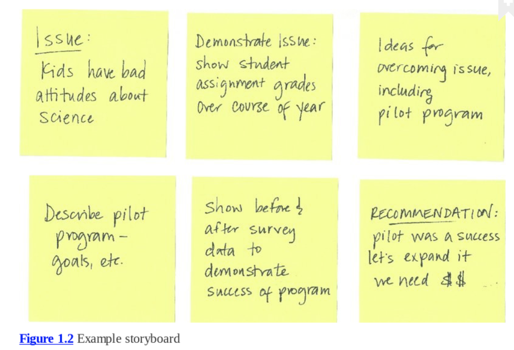

– Knaflic (2015)

## Storyboarding – Practice

What are the elements of your data story?

## Basic Structure

1. Provide context, so everyone is on common ground
2. What is the main question? Give examples that illustrate the issue.
3. Be concise, but provide enough information to contextualize visualizations
4. Use interactions wisely
5. Go from more general to more specific

## Example of data storytelling

Check [the pudding website](https://pudding.cool/), in particulate [the story about what it takes for groups to win](https://pudding.cool/2021/08/nba-carry/) and discuss with a classmate:

1. What is the 3-minute story?
2. What is the Big Idea
3. Did the authors provide enough context? How so?
4. What is the main question? What examples were provided?
5. Where the visualizations used effective?
6. How was interaction used?

## Another example

The [birthday paradox](https://pudding.cool/2018/04/birthday-paradox/) is quite different from the stories we’ve explored so far.

- What is the audience for this story?
- What is the 3-minute story?
- What is the Big Idea?
- How is context provided?
- How are visualizations used?

## Your data story

- What visualizations would you use for your data story?
- How would you use interaction and storytelling elements?